# ou20271_EMATM0061_B

Giannis Alexandrou

11/28/2020

# Section B: Statistical hypothesis testing

## **Unpaired Student’s t-test**

The statistical hypothesis testing that we are about to investigate is the unpaired Student’s t-test. An unpaired Student’s t-test is a statistical test that compares the means of two independent groups to determine if there is a notable difference between them.

#### **Hypotheses of an unpaired t-test**

There are two hypotheses in this test, $\mathbf{H}_0$ and $\mathbf{H}_1$ that are the same as the paired t-test.

- Null hypothesis ($\mathbf{H}_0$): The default position in a statistical hypothesis that typically declares the absence of an interesting phenomenon such as the equality of two statistical parameters like mean value.
- Alternative hypothesis ($\mathbf{H}_1$): A statistical hypothesis that contradicts the null hypothesis and typically declares the presence of some interesting phenomenon, often consistent with the research hypothesis a scientist is attempting to prove. For example, a difference in the values of two statistical parameters.

#### **Assumption of an unpaired t-test**

After forming the Statistical hypothesis with these two hypotheses, we need to apply model checking to validate any modeling assumptions. We must check that the statistical model underlying our hypotheses is reasonable. The assumptions that are required are:

- the data of the two unrelated groups are independent and identically distributed with a Gaussian distribution,
  - $\mathbf{X}_1^{0},...,\mathbf{X}_{n_0}^{0} \sim N(μ_0,σ_0)$, $\mathbf{X}_1^{1},...,\mathbf{X}_{n_1}^{1} \sim N(μ_1,σ_1)$
- the variance of data is the same between groups, meaning that they have the same standard deviation. [1]
  - $\mathbf{σ}_0^{2}=\mathbf{σ}_1^{2}$

#### **Choosing a significance level**

After model checking, we need to choose our desired significance level, which is an upper bound on the size of the test, typically set as 0.05.

- We choose a significance level e.g $a=0.05$

Then, we compute the numerical value of the test statistic from the data.

#### **Test statistics**

Then, we compute the numerical value of the test statistic from the data.

Test statistic is a function that has a known distribution under the null hypothesis and should emphasize the difference between null and alternative hypothesis. If the absolute result of the test statistic ($|Τ|$), is relatively large, then the two variances of hypotheses are not equal, while if it is relatively small, the two variances are equal.

#### **Computing the p-value**

Finally, we compute the p-value of the unpaired Student t-test which is the probability under the null hypothesis that the test statistic takes a value as extreme or more extreme than the observed value.

if the p-value is lower than the significance level, the observed data is sufficiently inconsistent with the null hypothesis and the null hypothesis can be reasonably rejected.[2] Thus, we can conclude that ($\mathbf{μ}_0 \neq \mathbf{μ}_1$)

However, if the p-value is bigger than the significance level, we need to accept the null hypothesis and conclude that ($\mathbf{μ}_0 = \mathbf{μ}_1$)

## **Simulation study to investigate the probability of type I error**

The test size of a test is the probability of Type I error under the null hypothesis:

- $\mathbf{a}_{test} = P(Type I error | \mathbf{H}_0 is true)$

The significance level of a test is an upper bound on the test size:

- $\mathbf{α}_{test} \le α$ with $α=0.05$

We created a function called “one_sample_t_test_with_null”. The function one_sample_t_test_with_null() will take the following three arguments: 1. The significance level of the test

2. The size of the first random sample
3. The size of the second random sample

The function will generate two random vectors $\mathbf{X}_0$ and $\mathbf{X}_1$ that containing i.i.d samples:

- $\mathbf{X}_1^{0},...,\mathbf{X}_{n_0}^{0} \sim N(μ_0,σ_0)$, and
- $\mathbf{X}_1^{1},...,\mathbf{X}_{n_1}^{1} \sim N(μ_1,σ_1)$

with different sample sizes.

The function should then perform an unpaired Stutent’s t-test to test the hypothesis that $μ_0=μ_1$. The result of the unpaired t-test will depend upon the significance level α equal to the value with argument “significance_level”. The output is a single Boolean which will be TRUE if the null is rejected and FALSE otherwise.

```r
one_sample_t_test_with_null<-function(significance_level,sample_size_1,sample_size_2){

  gaussian_sample_1 <- rnorm(sample_size_1,0.7) # create the first gaussian sample
  gaussian_sample_2 <- rnorm(sample_size_2,0.6) # create the second gaussian sample

  t_stats<-t.test(gaussian_sample_1,gaussian_sample_2,paired = FALSE) # carry out the unpaired Student's t-test
  p_val<-t_stats$p.value # extract p-value

  reject_null<-p_val<significance_level # make a decision
  return(reject_null)
}
```

Next we use the one_sample_t_test_with_null() to explore the probability of type I error as a function of the significance level.

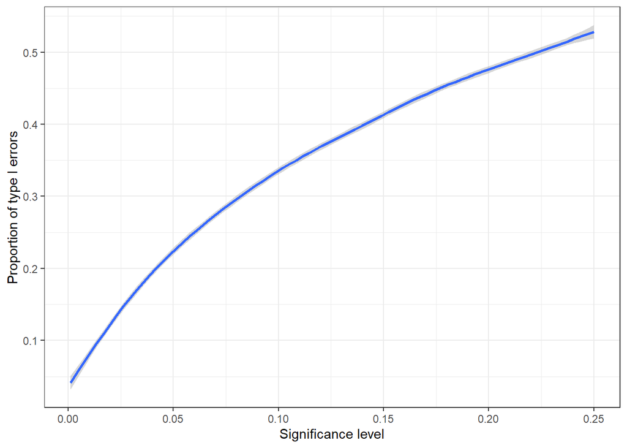

```r
set.seed(123) #  Ensures that we get the same result if we start with that same seed each time we run the same process
num_trials<-1000
alpha_inc<-0.001
sample_size_1<- 410
sample_size_2 <- 225

trials<-seq(num_trials) # number of trials
alphas<-seq(alpha_inc,0.25,alpha_inc) #different values of the significance level


cross_df(list(trial=trials,alpha=alphas))%>%
  mutate(reject_null=map_dbl(alpha,
                             ~as.numeric(one_sample_t_test_with_null(
    .x,sample_size_1,sample_size_2))))%>%
  ggplot(aes(x=alpha,y=reject_null))+
  geom_smooth()+theme_bw()+
  labs(x="Significance level", y="Proportion of type I errors")
```

## **Applying the hypothesis test to a suitable real-world data-set**

#### **Data Collection and Preparation**

For the statistical hypothesis testing I decided to use the dataset **“Heart Disease UCI”** from the Kaggle website. (URL: **https://www.kaggle.com/ronitf/heart-disease-uci**) [5].

```r
  df <- read.csv("heart.csv") #read the csv file and convert it into dataframe
```

This dataset contains 303 instances and 76 attributes but all published experiments refer to using a subset of 14 of them. The column names that are presented in the dataset are:

- age, sex, chest pain type, resting blood pressure, serum cholestoral, fasting blood sugar, resting electrocardiographic results, maximum heart rate achieved, exercise induced angina, oldpeak, slope, number of major vessels (0-3) colored by flourosopy and thal.

For the experiment, I executed an unpaired Student’s t-test, comparing the means of two independent groups to determine if there is a notable difference between them. Hence, I grouped the data into the sex of patients, male and female, and the purpose of the experiment is to assess if there is any difference between the average levels of cholesterol of the patient’s sex.

```r
  df %>% group_by(sex) %>% summarise(number=n()) %>% drop_na() #group the dataframe by the gender and drop the null row values
```

```
## # A tibble: 2 x 2
##     sex number
##   <int>  <int>
## 1     0     96
## 2     1    207
```

```r
  df %>% dim()
```

```
## [1] 303  14
```

The experimented data-set consists of 96 women and 207 men.

#### **Assign the hypotheses**

We start our hypothesis testing by assigning the null and alternative hypothesis:

- $H_0$ : The mean value of the average levels of cholesterol of the patient’s sex are equal
  - $μ_0=μ_1$
- $Η_1$ : The mean value of the average levels of cholesterol of the patient’s sex are differed
  - $μ_0 \ne μ_1$

```r
#We referred to values "0" as women and values "1" as men
  temp_df <- df
  for (i in 1:dim(df)[1]) {
    if(temp_df$sex[i]=='1'){
      temp_df$sex[i] = 'Male'
    }
    else {
      temp_df$sex[i] = 'Female'
    }
  }
```

#### **Model checking assumptions**

We must check that the statistical model underlying our hypotheses are reasonable.

We assume a Gaussian model : $\mathbf{X}_1^{0},...,\mathbf{X}_{n_0}^{0} \sim N(μ_0,σ_0)$ & $\mathbf{X}_1^{1},...,\mathbf{X}_{n_1}^{1} \sim N(μ_1,σ_1)$

To see if the assumption of both approximately Gaussian distributions are reasonable I created a kernel density plot containing both groups’ density and a quantile-quantile plot for each group.

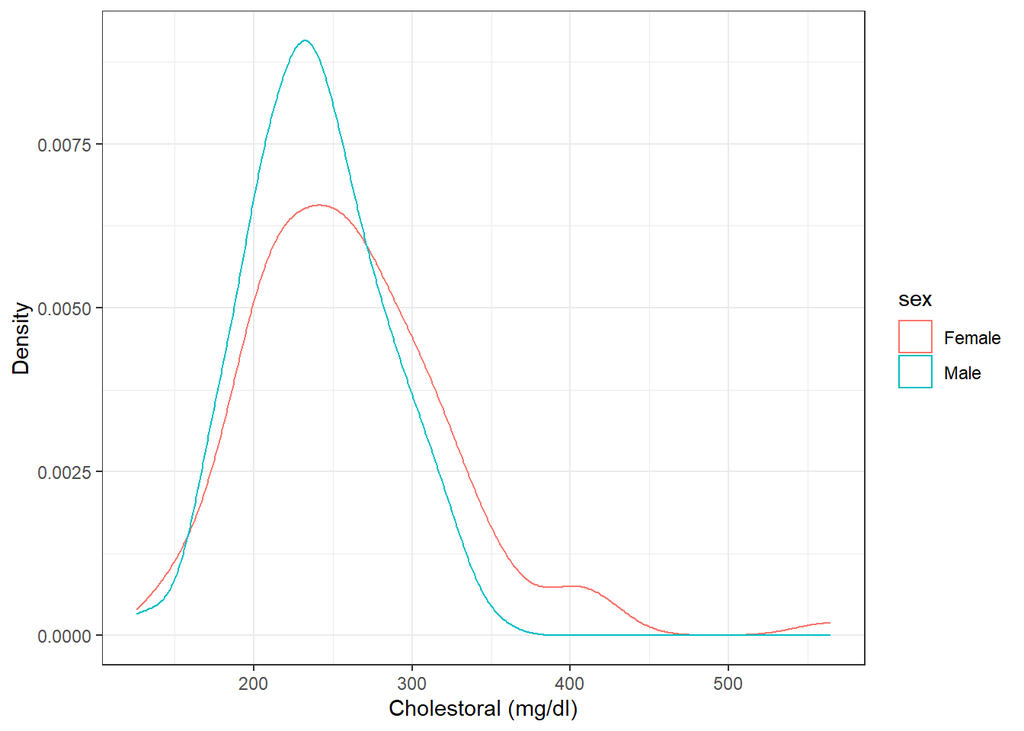

```r
  # A Gaussian Density plot for the two types of sex
  tibble(temp_df) %>% ggplot(aes(x=chol,color=sex)) + geom_density() + theme_bw() + xlab("Cholestoral (mg/dl)") + ylab("Density")
```

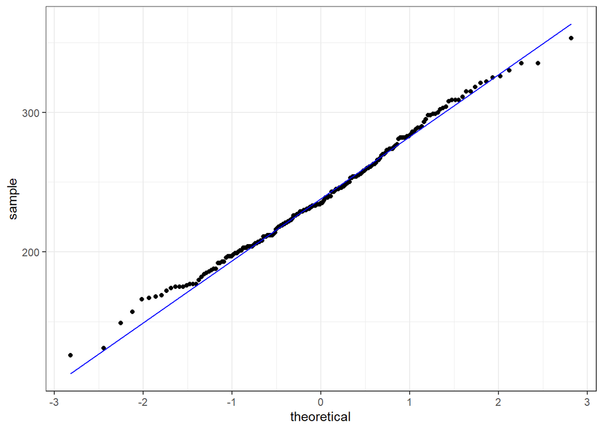

```r
  # Distribution of men's sample of data
  df %>% filter(sex==1) %>% select(chol) %>% ggplot(aes(sample=chol)) + stat_qq() + stat_qq_line(color="blue") + theme_bw()
```

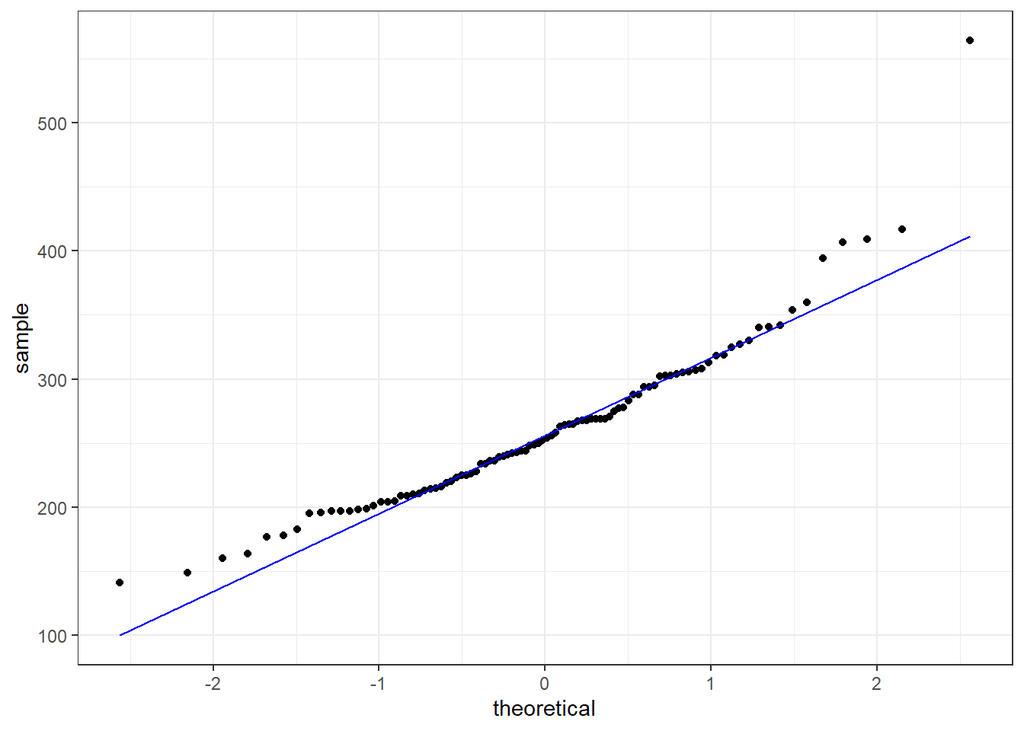

```r
  # Distribution of women's sample of data
  df %>% filter(sex==0) %>% select(chol) %>% ggplot(aes(sample=chol)) + stat_qq() + stat_qq_line(color="blue") + theme_bw()
```

As we can see from the two above plots, the sample quantiles are for the most part closely aligned with the theoretical quantiles. Most of the instances are centered into a particular range of values. Hence, by the central limit theorem, the sample means will be approximately Gaussian.

#### **Computing the test statistic**

Assuming for now that our assumption of approximate Gaussianity is justified we proceed with an unpaired Student’s t-test. We can carry out the unpaired t-test with R’s in built t.test() function. The significance level we decided to carrying out the analysis is set to 0.05 (α=0.05)

```r
  result_test <- t.test(chol~sex, data = temp_df, var.equal = TRUE) #
  result_test
```

```
##
##  Two Sample t-test
##
## data:  chol by sex
## t = 3.5029, df = 301, p-value = 0.00053
## alternative hypothesis: true difference in means is not equal to 0
## 95 percent confidence interval:
##   9.64622 34.37824
## sample estimates:
## mean in group Female   mean in group Male
##             261.3021             239.2899
```

## **Statistical conclusion**

The $p-value = 0.00053$ is far below the significance level of $α=0.05$ and hence we can reject the null hypothesis. That mean the alternative hypothesis is accepted and the mean values of populations are not equal.

The test-statistic has positive value, which means female’s mean value is bigger than male’s mean value,

- $μ_0 = 261.3021$ -> Female
- $μ_1 = 239.2899$ -> Male

Therefore, we conclude from the statistical test that the female patients have bigger average levels of cholesterol than the male patients on average.

Moreover, we need consider about the effect size for assessing the magnitude of difference especially now that the null hypothesis has been rejected.

According to Cohen’s d statistic [4], the following guidelines for interpreting the effect size are:

- Below 0.2 - small effect
- Around 0.5 - medium effect
- Larger than 0.8 - A large effect

```r
results <- df %>% cohens_d(
  chol ~ sex, var.equal = TRUE,
  hedges.correction = TRUE
  )
results
```

```
## # A tibble: 1 x 7
##   .y.   group1 group2 effsize    n1    n2 magnitude
## * <chr> <chr>  <chr>    <dbl> <int> <int> <ord>
## 1 chol  0      1        0.431    96   207 small
```

```r
effect_size <- results$effsize
effect_size
```

```
## Cohen's d
## 0.4314679
```

We may also have the option to select a different unpaired t-test, the Mann-Whitney-Wilcoxon test. The reason that we decided to follow the Student’s t-test approach was :

1. Both of the sample sizes were small
2. Both of the populations were checked as a Gaussian distribution

## **Observational study**

Overall, the statistical experiment that we investigated was targeted as an Observational Study. [3] The statistical test was about observing the difference between the averages of gender’s cholesterol from an experiment sample that was focusing on Heart Diseases. Hence our study wasn’t focusing on causal effects.

Surely, there are some potential obstacles that we need to consider in order to draw a valid scientific conclusion about the two samples that we investigated.

One obstacle is the Selection bias. It happens when the data included in the analysis is misrepresented the underlying population of interest. There are also different forms of bias. In our study, we may suffer from sample bias. Sample bias happens when some members of your intended population are more likely to be sampled than others. We conducted a survey from the Cleveland Clinic Foundation database from patients related to heart diseases. Our study observes and concludes two samples which related to Cleveland’s patients and not to the patients globally. Thus, we are not sure, if this experiment is representative of the population of heart disease patients worldwide.

## **References**

[1] Technology Networks. (2020, February 14). Paired vs Unpaired T-Test: Differences, Assumptions and Hypotheses. Retrieved from https://www.technologynetworks.com/informatics/articles/paired-vs-unpaired-t-test-differences-assumptions-and-hypotheses-330826

[2] P-value. (2021, January 03). Retrieved from https://en.wikipedia.org/wiki/P-value

[3] Observational studies and experiments (article). (n.d.). Retrieved from https://www.khanacademy.org/math/ap-statistics/gathering-data-ap/types-of-studies-experimental-vs-observational/a/observational-studies-and-experiments

[4] T-test Effect Size using Cohen’s d Measure : Excellent Tutorial. (n.d.). Retrieved from https://www.datanovia.com/en/lessons/t-test-effect-size-using-cohens-d-measure/

[5] Ronit. (2018, June 25). Heart Disease UCI. Retrieved from https://www.kaggle.com/ronitf/heart-disease-uci